# Script 5 - Impact of infection on movement

Blood parasites and avian health

Marie Buysse, Mathilde Ollagnier, Charly Souc, Marjorie Bruley, Thomas Blanchon, Carole Leray, Marion Vittecoq and Karen D. McCoy

# 0.Librairies

```r
library(readxl) #read_excel function
library(ggplot2)
library(dplyr)
library(kableExtra) #kable function
library(ggpubr) #ggarrange function
library(lme4) #lmer function
library(sjPlot) #tab_model function
library(DHARMa) #simulateResiduals function
library(MuMIn) #AICc function
library(car) #leveneTest function
library(coin) #oneway_test and wilcox_test functions
library(mgcv) #gam function
library(fitdistrplus) #fitdist function
library(emmeans) #emmeans function
library(dplyr) #group_by and group_split functions
library(sf) #SF object manipulation
library(trajr) #TrajFromCoords and TrajLength functions
library(lubridate) #date manipulation
```

**Information about data visualisation:**  
For a same variable, one data visualisation is based on fixed effect selected in the best-fitted model and most significant random effects. Another visualisation include the infection status or parasitemia, whether significant or not.

# 1. Infection status influence on fledging and migration

## 1.1. Dataset

```r
data_Fledg_Mig <- read_excel("Data_Impact of infection on movement_fledging_migration.xlsx")
data_Fledg_Mig$Sample <- as.factor(data_Fledg_Mig$Sample)
data_Fledg_Mig$Site <- as.factor(data_Fledg_Mig$Site)
data_Fledg_Mig$Year <- as.factor(data_Fledg_Mig$Year)
data_Fledg_Mig$Sex <- as.factor(data_Fledg_Mig$Sex)
data_Fledg_Mig$Status_qPCR <- as.factor(data_Fledg_Mig$Status_qPCR)
data_Fledg_Mig$Fledging_day <- as.numeric(data_Fledg_Mig$Fledging_day)
data_Fledg_Mig$Migration_day <- as.numeric(data_Fledg_Mig$Migration_day)
data_Fledg_Mig$Migration <- as.numeric(data_Fledg_Mig$Migration)
data_Fledg_Mig$Avg_distance_km <- as.numeric(data_Fledg_Mig$Avg_distance_km)
```

With:  
-Sample: ID of individual bird  
-Site: sampling colony (Carteau/Frioul)  
-Year: sampling year (2022/2023/2024)  
-Sex: sex of bird (F/M)  
-Status_qPCR: infection status based on qPCR technique (uninfected/infected)  
-Fledging_day: age of fledging (in days)  
-Migration_day: age of departure on migration (in days)  
-Migration: migration strategy (1: migratory or 0: non-migratory)  
-Avg_distance_km: average daily flight distance between fledging and September 1st (in kilometers)

## 1.2. Infection status influence on fledging age

Individuals for whom `Fledging_day` hasn’t been determined are removed:

```r
data_Fledg_age <- data_Fledg_Mig %>%
  filter(!is.na(Fledging_day))
```

### 1.2.1. Data distribution

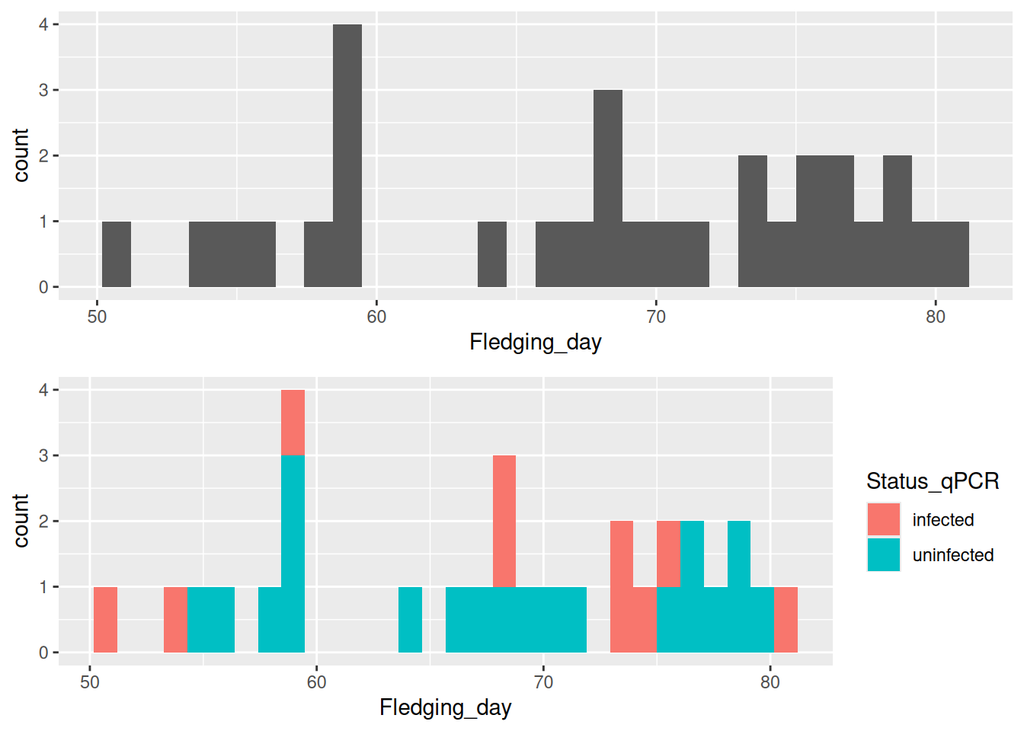

```r
g <- ggplot(data_Fledg_age, aes(x=Fledging_day)) + geom_histogram()
h <- ggplot(data_Fledg_age, aes(x=Fledging_day, fill=Status_qPCR)) + geom_histogram()
ggarrange(g,h, ncol=1, nrow=2)
```

```r
shap1 <- shapiro.test(data_Fledg_age$Fledging_day)
shap2 <- shapiro.test(data_Fledg_age$Fledging_day[data_Fledg_age$Status_qPCR == "infected"])
shap3 <- shapiro.test(data_Fledg_age$Fledging_day[data_Fledg_age$Status_qPCR == "uninfected"])

shapiro_test_results <- data.frame(
  Shapiro_test = c("Fledging_day", "Fledging_day - infected", "Fledging_day - uninfected"),
  p_value = c(shap1$p.value, shap2$p.value, shap3$p.value))

shapiro_test_results %>%
  kable(caption = "Shapiro results of Fledging_day") %>%
  kable_styling(bootstrap_options = c("striped", "hover", "condensed", "responsive"))
```

Shapiro results of Fledging_day

| Shapiro_test | p_value |
| --- | --- |
| Fledging_day | 0.0734276 |
| Fledging_day - infected | 0.3341566 |
| Fledging_day - uninfected | 0.0660456 |

**All p-value > 0.05**

```r
leveneTest(data_Fledg_age$Fledging_day ~ data_Fledg_age$Status_qPCR)
```

```
## Levene's Test for Homogeneity of Variance (center = median)
##       Df F value Pr(>F)
## group  1  0.0793 0.7803
##       28
```

**p-value > 0.05**  
Variances are egal and `data_Fledg_age$Fledging_day` is normally distributed. **We will use parametric tests and LMER models (while testing the distribution of model residuals).**

### 1.2.2. Two Sample t-test

```r
t.test(data_Fledg_age$Fledging_day ~ data_Fledg_age$Status_qPCR, var.equal = TRUE)
```

```
##
##  Two Sample t-test
##
## data:  data_Fledg_age$Fledging_day by data_Fledg_age$Status_qPCR
## t = -0.15675, df = 28, p-value = 0.8766
## alternative hypothesis: true difference in means between group infected and group uninfected is not equal to 0
## 95 percent confidence interval:
##  -7.737404  6.637404
## sample estimates:
##   mean in group infected mean in group uninfected
##                    67.80                    68.35
```

**p = 0.8766 > 0.05**  
**There is no difference in mean days of fledging between infection status**. The average number of days for infected birds is 67.80 days and for non-infected birds it is 68.35 days.

Some metrics:

```r
summary_fled_age <- data_Fledg_age %>%
  group_by(Status_qPCR) %>%
  summarise(
    mean = mean(Fledging_day, na.rm = TRUE),
    SD = sd(Fledging_day),
    SE = sd(Fledging_day, na.rm = TRUE) / sqrt(length(Fledging_day)),
    n = length(Fledging_day)
    )
kable(summary_fled_age, align="lccc")
```

| Status_qPCR | mean | SD | SE | n |
| --- | --- | --- | --- | --- |
| infected | 67.80 | 9.986658 | 3.158059 | 10 |
| uninfected | 68.35 | 8.585637 | 1.919807 | 20 |

### 1.2.3. Model LMER

We include the variables `Status_qPCR` as a fixed effect and `Site`, `Year` and `Sex` as random effects in our full LMER model:

```r
lmer_full_fled_age <- lmer(Fledging_day ~ Status_qPCR + (1|Site) + (1|Year) + (1|Sex), data=data_Fledg_age)
lmer_null_fled_age <- lmer(Fledging_day ~ 1 + (1|Site) + (1|Year) + (1|Sex), data=data_Fledg_age)
AICc(lmer_full_fled_age)
```

```
## [1] 202.8934
```

```r
AICc(lmer_null_fled_age)
```

```
## [1] 204.584
```

```r
anova(lmer_full_fled_age, lmer_null_fled_age, test="Chisq")
```

```
## Data: data_Fledg_age
## Models:
## lmer_null_fled_age: Fledging_day ~ 1 + (1 | Site) + (1 | Year) + (1 | Sex)
## lmer_full_fled_age: Fledging_day ~ Status_qPCR + (1 | Site) + (1 | Year) + (1 | Sex)
##                    npar    AIC    BIC  logLik -2*log(L)  Chisq Df Pr(>Chisq)
## lmer_null_fled_age    5 206.69 213.35 -98.346    196.69
## lmer_full_fled_age    6 207.93 215.93 -97.966    195.93 0.7609  1     0.3831
```

```r
tab_model(lmer_full_fled_age, lmer_null_fled_age, string.est = "IRR", show.aicc = TRUE, digits=2, show.ci = FALSE, show.intercept = FALSE)
```

|  | Fledging_day |  | Fledging_day |  |
| --- | --- | --- | --- | --- |
| Predictors | IRR | p | IRR | p |
| Status qPCR [uninfected] | 2.95 | 0.378 |  |  |
| Random Effects |  |  |  |  |
| σ<sup>2</sup> | 52.61 |  | 52.73 |  |
| τ<sub>00</sub> | 31.58 <sub>Year</sub> |  | 23.80 <sub>Year</sub> |  |
|  | 22.74 <sub>Sex</sub> |  | 27.67 <sub>Sex</sub> |  |
|  | 0.00 <sub>Site</sub> |  | 0.00 <sub>Site</sub> |  |
| N | 2 <sub>Site</sub> |  | 2 <sub>Site</sub> |  |
|  | 3 <sub>Year</sub> |  | 3 <sub>Year</sub> |  |
|  | 2 <sub>Sex</sub> |  | 2 <sub>Sex</sub> |  |
| Observations | 28 |  | 28 |  |
| Marginal R<sup>2</sup> / Conditional R<sup>2</sup> | 0.038 / NA |  | 0.000 / NA |  |
| AICc | 202.893 |  | 204.584 |  |

Based on these results, **`Status_qPCR` is not a fixed effect influencing the fledging age.**

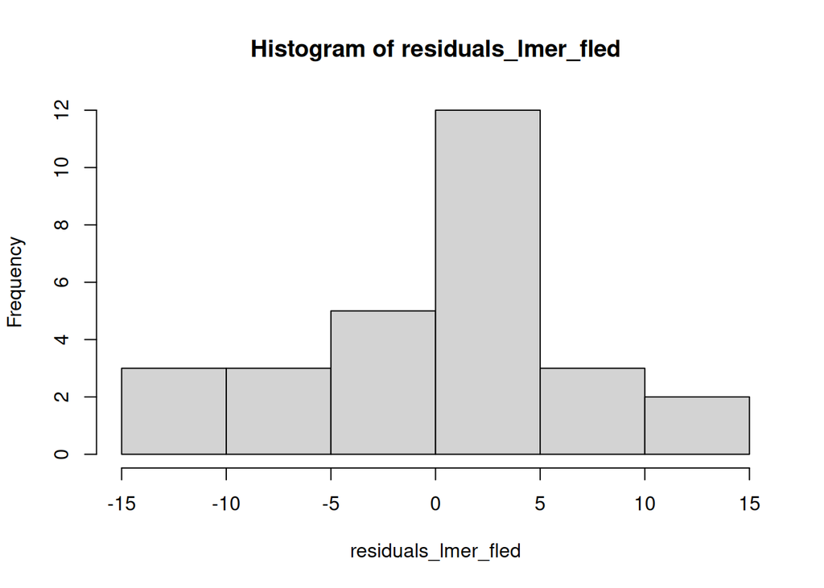

```r
residuals_lmer_fled <- residuals(lmer_null_fled_age)
hist(residuals_lmer_fled)
```

```r
shapiro.test(residuals(lmer_null_fled_age))
```

```
##
##  Shapiro-Wilk normality test
##
## data:  residuals(lmer_null_fled_age)
## W = 0.97571, p-value = 0.7383
```

Visualisation:

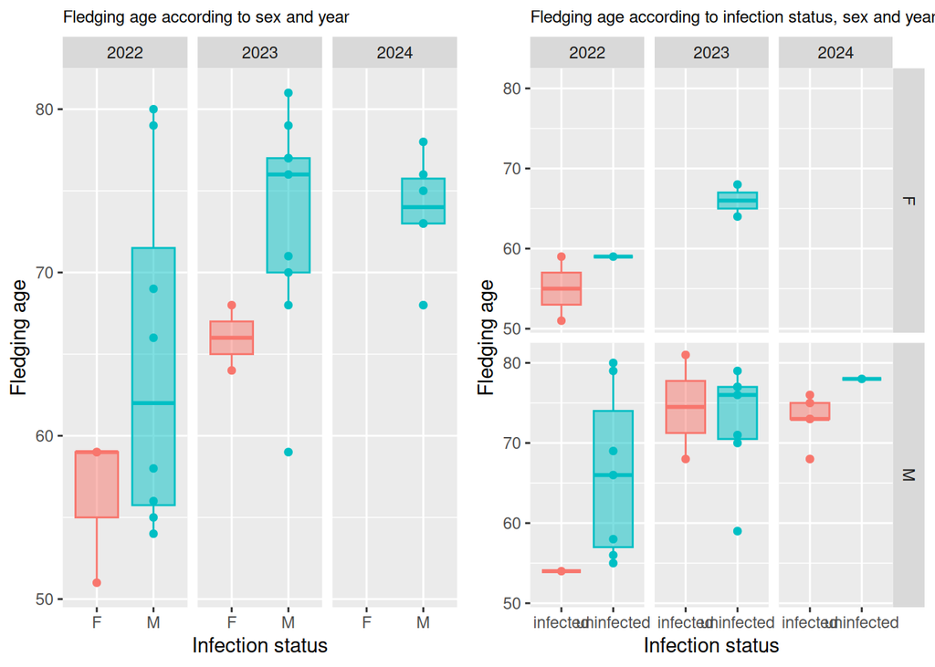

```r
data_Fledg_age <- data_Fledg_age %>%
  filter(!is.na(Sex))

plotA <- ggplot(data_Fledg_age, aes(x = Sex, y = Fledging_day, fill = Sex, col= Sex)) +
  geom_point() +
  geom_boxplot(alpha = 0.5) +
  labs(y = "Fledging age",
       x = "Infection status",
       title = "Fledging age according to sex and year") +
  theme(plot.title = element_text(size = 9),
    legend.position = "none"
  ) +
  facet_grid(~Year)

plotB <- ggplot(data_Fledg_age, aes(x = Status_qPCR, y = Fledging_day, fill = Status_qPCR, col= Status_qPCR)) +
  geom_point() +
  geom_boxplot(alpha = 0.5) +
  labs(y = "Fledging age",
       x = "Infection status",
       title = "Fledging age according to infection status, sex and year") +
  theme(plot.title = element_text(size = 9),
    legend.position = "none"
  ) +
  facet_grid(Sex~Year)

ggarrange(plotA, plotB, ncol=2, nrow=1)
```

## 1.3. Infection status influence on the overall migration strategy (migratory or non-migratory)

```r
data_Migr <- data_Fledg_Mig %>%
  filter(!is.na(Migration))
```

### 1.3.1. Fisher’s test

```r
tabCont_migration <- table(data_Migr$Migration, data_Migr$Status_qPCR)
tabCont_migration_marg <- addmargins(tabCont_migration)
print(tabCont_migration_marg)
```

```
##
##       infected uninfected Sum
##   0          5          9  14
##   1          9         14  23
##   Sum       14         23  37
```

```r
fisher.test(tabCont_migration, simulate.p.value = TRUE, B = 10000)
```

```
##
##  Fisher's Exact Test for Count Data
##
## data:  tabCont_migration
## p-value = 1
## alternative hypothesis: true odds ratio is not equal to 1
## 95 percent confidence interval:
##  0.169397 4.131221
## sample estimates:
## odds ratio
##   0.867601
```

**p-value = 1**  
**We therefore consider that the proportions are not significantly different based on the infection status**.

### 1.3.2. Model GLMER

We include the variables `Status_qPCR` as a fixed effect and `Site`, `Year` and `Sex` as random effects in our full GLMER model (binomial family):

```r
glmer_full_migr <- glmer(Migration ~ Status_qPCR + (1|Site) + (1|Year) + (1|Sex), family=binomial(link = "logit"), data=data_Migr)
glmer_null_migr <- glmer(Migration ~ 1 + (1|Site) + (1|Year) + (1|Sex), family=binomial(link = "logit"), data=data_Migr)
AICc(glmer_full_migr)
```

```
## [1] 58.84373
```

```r
AICc(glmer_null_migr)
```

```
## [1] 56.34877
```

```r
anova(glmer_full_migr, glmer_null_migr, test="Chisq")
```

```
## Data: data_Migr
## Models:
## glmer_null_migr: Migration ~ 1 + (1 | Site) + (1 | Year) + (1 | Sex)
## glmer_full_migr: Migration ~ Status_qPCR + (1 | Site) + (1 | Year) + (1 | Sex)
##                 npar    AIC    BIC  logLik -2*log(L)  Chisq Df Pr(>Chisq)
## glmer_null_migr    4 55.058 61.393 -23.529    47.058
## glmer_full_migr    5 56.844 64.761 -23.422    46.844 0.2147  1     0.6431
```

```r
tab_model(glmer_full_migr, glmer_null_migr, string.est = "IRR", show.aicc = TRUE, digits=2, show.ci = FALSE, show.intercept = FALSE)
```

|  | Migration |  | Migration |  |
| --- | --- | --- | --- | --- |
| Predictors | IRR | p | IRR | p |
| Status qPCR [uninfected] | 2.50 | 0.620 |  |  |
| Random Effects |  |  |  |  |
| σ<sup>2</sup> | 3.29 |  | 3.29 |  |
| τ<sub>00</sub> | 0.00 <sub>Year</sub> |  | 0.00 <sub>Year</sub> |  |
|  | 0.00 <sub>Sex</sub> |  | 0.00 <sub>Sex</sub> |  |
|  | 0.55 <sub>Site</sub> |  | 0.05 <sub>Site</sub> |  |
| N | 2 <sub>Site</sub> |  | 2 <sub>Site</sub> |  |
|  | 3 <sub>Year</sub> |  | 3 <sub>Year</sub> |  |
|  | 2 <sub>Sex</sub> |  | 2 <sub>Sex</sub> |  |
| Observations | 36 |  | 36 |  |
| Marginal R<sup>2</sup> / Conditional R<sup>2</sup> | 0.059 / NA |  | 0.000 / NA |  |
| AICc | 58.844 |  | 56.349 |  |

Based on these results, **`Status_qPCR` is not a fixed effect influencing the overall migration strategy.**

Visualisation:

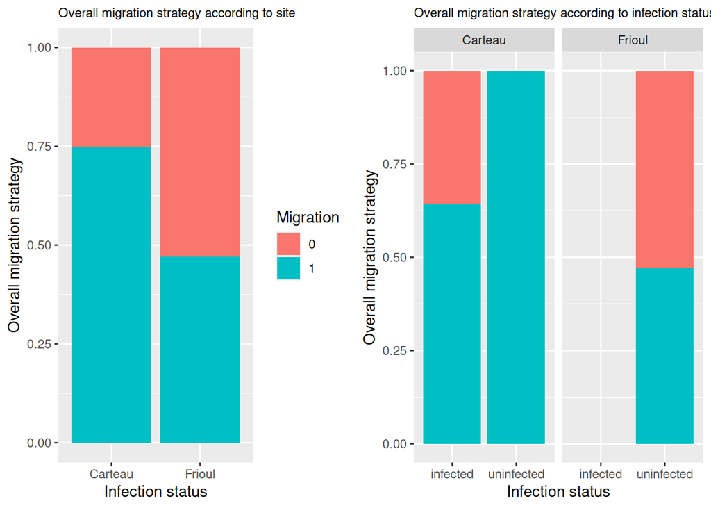

```r
plotC <- ggplot(data_Migr, aes(x = Site, fill = factor(Migration))) +
  geom_bar(position = "fill") +
  labs(y = "Overall migration strategy",
       x = "Infection status",
       title = "Overall migration strategy according to site",
       fill = "Migration") +
  theme(plot.title = element_text(size = 9))

plotD <- ggplot(data_Migr, aes(x = Status_qPCR, fill = factor(Migration))) +
  geom_bar(position = "fill") +
  labs(y = "Overall migration strategy",
       x = "Infection status",
       title = "Overall migration strategy according to infection status and site",
       fill = "Migration") +
  theme(plot.title = element_text(size = 9),
        legend.position = "none") +
  facet_grid(~Site)

ggarrange(plotC, plotD, ncol=2, nrow=1)
```

## 1.4. Infection status influence on age of departure on migration (for individuals that migrated)

Individuals for whom `Migration_day` hasn’t been determined are removed:

```r
data_Migr_age <- data_Fledg_Mig %>%
  filter(!is.na(Migration_day))
```

### 1.4.1. Data distribution

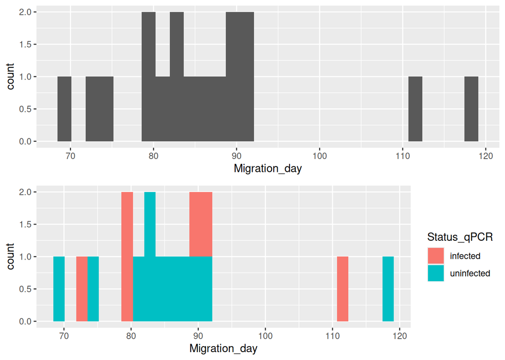

```r
g <- ggplot(data_Migr_age, aes(x=Migration_day)) + geom_histogram()
h <- ggplot(data_Migr_age, aes(x=Migration_day, fill=Status_qPCR)) + geom_histogram()
ggarrange(g,h, ncol=1, nrow=2)
```

```r
shap4 <- shapiro.test(data_Migr_age$Migration_day)
shap5 <- shapiro.test(data_Migr_age$Migration_day[data_Migr_age$Status_qPCR == "infected"])
shap6 <- shapiro.test(data_Migr_age$Migration_day[data_Migr_age$Status_qPCR == "uninfected"])

shapiro_test_results <- data.frame(
  Shapiro_test = c("Migration_day", "Migration_day - infected", "Migration_day - uninfected"),
  p_value = c(shap4$p.value, shap5$p.value, shap6$p.value))

shapiro_test_results %>%
  kable(caption = "Shapiro results of Migration_day") %>%
  kable_styling(bootstrap_options = c("striped", "hover", "condensed", "responsive"))
```

Shapiro results of Migration_day

| Shapiro_test | p_value |
| --- | --- |
| Migration_day | 0.0209818 |
| Migration_day - infected | 0.4345532 |
| Migration_day - uninfected | 0.0251290 |

**p-value of Migration_day < 0.05**

```r
leveneTest(data_Migr_age$Migration_day ~ data_Migr_age$Status_qPCR)
```

```
## Levene's Test for Homogeneity of Variance (center = median)
##       Df F value Pr(>F)
## group  1  0.2993 0.5924
##       15
```

**p-value > 0.05**  
Variances are egal but `data_Migr_age$Migration_day` is not normally distributed. **We will use non-parametric tests but LMER models for which we will test the distribution of model residuals.**

### 1.4.2. Wilcoxon rank-sum test and permutation-based one-way test

```r
wilcox.test(Migration_day ~ Status_qPCR, data = data_Migr_age, exact = TRUE)
```

```
##
##  Wilcoxon rank sum test with continuity correction
##
## data:  Migration_day by Status_qPCR
## W = 32.5, p-value = 1
## alternative hypothesis: true location shift is not equal to 0
```

**p-value = 1**  
We will use permutation-based tests to obtain an exact p-value.

```r
wilcox_test(Migration_day ~ Status_qPCR, data = data_Migr_age, distribution = "exact")
```

```
##
##  Exact Wilcoxon-Mann-Whitney Test
##
## data:  Migration_day by Status_qPCR (infected, uninfected)
## Z = -0.050314, p-value = 0.9809
## alternative hypothesis: true mu is not equal to 0
```

```r
oneway_test(Migration_day ~ Status_qPCR, data = data_Migr_age, distribution = "exact")
```

```
##
##  Exact Two-Sample Fisher-Pitman Permutation Test
##
## data:  Migration_day by Status_qPCR (infected, uninfected)
## Z = 0.15077, p-value = 0.9027
## alternative hypothesis: true mu is not equal to 0
```

**p-value = 0.9809 and 0.9027**  
**There is no difference in mean of the age of the departure on migration**.

### 1.4.3. Model LMER

We include the variables `Status_qPCR` as a fixed effect and `Site`, `Year` and `Sex` as random effects in our full LMER model:

```r
lmer_full_migr_age <- lmer(Migration_day ~ Status_qPCR + (1|Site) + (1|Year) + (1|Sex), data=data_Migr_age)
lmer_null_migr_age <- lmer(Migration_day ~ 1 + (1|Site) + (1|Year) + (1|Sex), data=data_Migr_age)
AICc(lmer_full_migr_age)
```

```
## [1] 143.7336
```

```r
AICc(lmer_null_migr_age)
```

```
## [1] 144.5595
```

```r
anova(lmer_full_migr_age, lmer_null_migr_age, test="Chisq")
```

```
## Data: data_Migr_age
## Models:
## lmer_null_migr_age: Migration_day ~ 1 + (1 | Site) + (1 | Year) + (1 | Sex)
## lmer_full_migr_age: Migration_day ~ Status_qPCR + (1 | Site) + (1 | Year) + (1 | Sex)
##                    npar    AIC    BIC  logLik -2*log(L)  Chisq Df Pr(>Chisq)
## lmer_null_migr_age    5 143.50 147.67 -66.751    133.50
## lmer_full_migr_age    6 145.49 150.49 -66.745    133.49 0.0116  1     0.9142
```

```r
tab_model(lmer_full_migr_age, lmer_null_migr_age, string.est = "IRR", show.aicc = TRUE, digits=2, show.ci = FALSE, show.intercept = FALSE)
```

|  | Migration_day |  | Migration_day |  |
| --- | --- | --- | --- | --- |
| Predictors | IRR | p | IRR | p |
| Status qPCR [uninfected] | -0.29 | 0.970 |  |  |
| Random Effects |  |  |  |  |
| σ<sup>2</sup> | 150.45 |  | 143.65 |  |
| τ<sub>00</sub> | 27.90 <sub>Year</sub> |  | 20.06 <sub>Year</sub> |  |
|  | 10.74 <sub>Sex</sub> |  | 8.54 <sub>Sex</sub> |  |
|  | 0.00 <sub>Site</sub> |  | 0.00 <sub>Site</sub> |  |
| ICC | 0.20 |  | 0.17 |  |
| N | 2 <sub>Site</sub> |  | 2 <sub>Site</sub> |  |
|  | 3 <sub>Year</sub> |  | 3 <sub>Year</sub> |  |
|  | 2 <sub>Sex</sub> |  | 2 <sub>Sex</sub> |  |
| Observations | 17 |  | 17 |  |
| Marginal R<sup>2</sup> / Conditional R<sup>2</sup> | 0.000 / 0.204 |  | 0.000 / 0.166 |  |
| AICc | 143.734 |  | 144.560 |  |

Based on these results, **`Status_qPCR` is not a fixed effect influencing the age of departure on migration.**

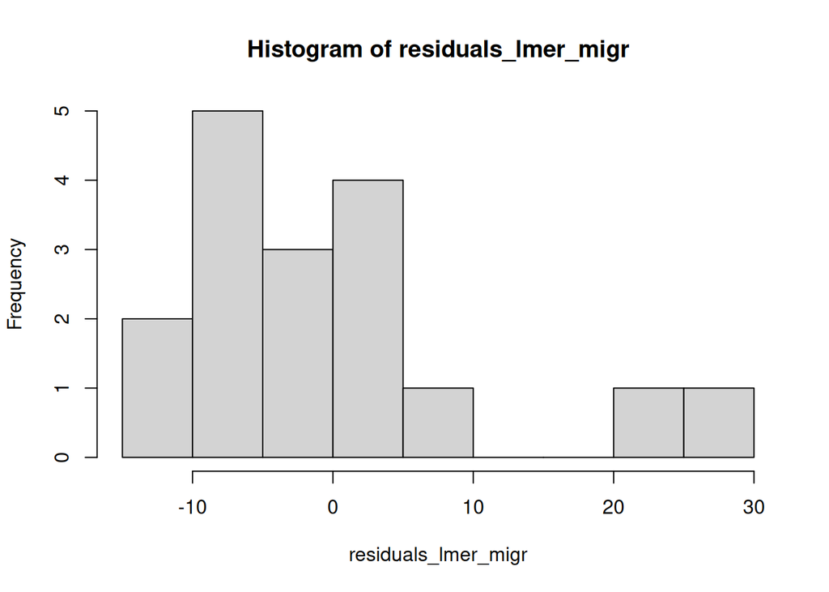

```r
residuals_lmer_migr <- residuals(lmer_null_migr_age)
hist(residuals_lmer_migr)
```

```r
shapiro.test(residuals(lmer_null_migr_age))
```

```
##
##  Shapiro-Wilk normality test
##
## data:  residuals(lmer_null_migr_age)
## W = 0.84549, p-value = 0.009161
```

Visualisation:

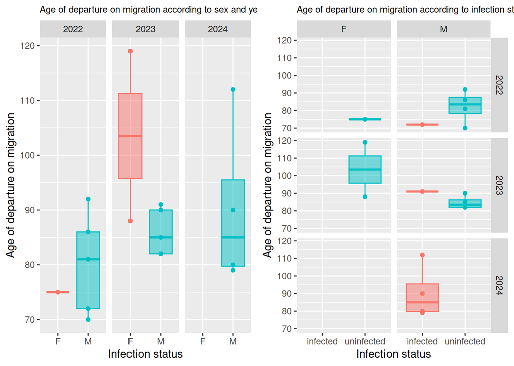

```r
plotE <- ggplot(data_Migr_age, aes(x = Sex, y = Migration_day, fill = Sex, col= Sex)) +
  geom_point() +
  geom_boxplot(alpha = 0.5) +
  labs(y = "Age of departure on migration",
       x = "Infection status",
       title = "Age of departure on migration according to sex and year") +
  theme(plot.title = element_text(size = 9),
    legend.position = "none"
  ) +
  facet_grid(~Year)

plotF <- ggplot(data_Migr_age, aes(x = Status_qPCR, y = Migration_day, fill = Status_qPCR, col= Status_qPCR)) +
  geom_point() +
  geom_boxplot(alpha = 0.5) +
  labs(y = "Age of departure on migration",
       x = "Infection status",
       title = "Age of departure on migration according to infection status, sex and year") +
  theme(plot.title = element_text(size = 9),
    legend.position = "none"
  ) +
  facet_grid(Year~Sex)

ggarrange(plotE, plotF, ncol=2, nrow=1)
```

# 2. Infection status influence on daily flight distances between fledging and September 1st

## 2.0. Calculation of `Day_distance_km` and `Avg_distance_km`

**Important**  
The dataset about the GPS location (`data_movement.csv`) is not shared in the GitHub repository. Nevertheless, access can be granted upon request via Movebank for relevant inquiries (Project ID: Yellow-Legged Gull - France - Espagne -ID_PROG 990).

```
data_movement <- read.csv("data_movement.csv", header = TRUE) #GPS positions of all tagged juveniles yellow-legged gull who have been included in the paper study from the day their GPS tag was deployed until the 1st of September).
data_movement$timestamp <- as.POSIXct(data_movement$timestamp, format = "%Y-%m-%d %H:%M:%S", tz = "UTC")
data_movement <- data_movement %>% mutate_at(vars(date, Hatching.date.estimate, date.de.fin), ~ as.POSIXct(., format = "%Y-%m-%d", tz = "UTC"))

#spatial files
buffer_carteau <- st_read("buffer_carteau200m.shp") %>% st_transform(4326) #Polygon of Carteau colony with a 200m buffer zone
buffer_frioul <- st_read("buffer_frioul200m.shp") %>% st_transform(4326)# Polygon of the studied part of Frioul colony with a 200m buffer zone
buffer_medit <- st_read("buffer_medit_80km.shp") %>% st_transform(4326)# Mediterranean Sea and a 80 km surrounding zone

#information about the individuals
data_ind <- read.csv2("gps_babesie.csv", header = TRUE)
```

`data_movement` includes the GPS positions of the individuals and associated information, with:  
-Site: sampling colony (Carteau/Frioul)  
-individual.local.identifier: ID of individual bird  
-location.long: longitude coordinates  
-location.lat: latitude coordinates  
-timestamp: time in “YYYY-MM-DD HH:MM:SS” format

`data_ind` includes the information about each individual, with:  
-Site: sampling colony (Carteau/Frioul)  
-Bague.Darvic: ID of individual bird  
-Year: sampling year (2022/2023/2024)  
-date.de.fin: date on wich the tag stopped transmitting  
-cause: cause of the transmission stoppage (mort/mort possible/perte de transmission) mort = dead, mort possible = loss of transmission with suspected death, perte de transmission = lost signal  
-hatching.date.estimate: Estimated hatching date

The following information are included but are not significant to the following command lines:  
-Nid: number of the Nest  
-date: Date of tag deployment  
-masse : Mass of the individual in grams  
-Sexe: sex of bird (F/M)  
-Statut: infection status (infected/uninfected/NA)  
-days: number of days since hatching  
-Tag.mass:Tag mass in grams (including the attachment system)  
-Tag.mass.percentage: Percentage of the tag’s mass relative to the total mass of the bird in %

### 2.0.1. Each position is associated with a buffer (colony, medit or migrant)

```
#conversion of data_movement to an SF object
movement_sf <- st_as_sf(data_movement, coords = c("location.long", "location.lat"), crs = 4326)

#create a column with True/False depending on whether the individual is inside or outside of the three buffers.
movement_sf$insidecarteau <- st_within(movement_sf, buffer_carteau, sparse = FALSE) %>% apply(1, any)
movement_sf$insidefrioul <- st_within(movement_sf, buffer_frioul, sparse = FALSE) %>% apply(1, any)
movement_sf$insidemedit <- st_within(movement_sf, buffer_medit, sparse = FALSE) %>% apply(1, any)

#add the column
movement_sf$loc <- NA
#if TRUE for insidecarteau, the individuals from Carteau can have the value "colony" in this column
movement_sf$loc[movement_sf$insidecarteau & movement_sf$Site == "Carteau"] <- "colony"
#if TRUE for insidefrioul, the individuals from Frioul can have the value "colony" in this column
movement_sf$loc[movement_sf$insidefrioul & movement_sf$Site == "Frioul"] <- "colony"
#If TRUE for insidemedit and the column loc does not contain "colony", then the rows can have the value "medit" in this column.
movement_sf$loc[movement_sf$insidemedit & is.na(movement_sf$loc)] <- "medit"
#If insidemedit is FALSE, then the rows can have the value "migrant" in this column.
movement_sf$loc[!movement_sf$insidemedit] <- "migrant"
```

### 2.0.2. Compute the days of fledging

```
#reconversion into a data.frame
data_movementv2 <- movement_sf %>% cbind(st_coordinates(.)) %>% as.data.frame()

#Computate the fledging day (ie: 10 succesive location outside the 200m buffer zone during 1h30 minimum)
result <- data_movementv2 %>%
  arrange(individual.local.identifier, timestamp) %>%  # arrange by individual & timestamp
  group_by(individual.local.identifier) %>%           # Groups by individuals
  mutate(
    # Identify the mediteranean position  ("medit") = outside the colony
    is_medit = loc == "medit",  # label
    sequence_id = cumsum(!is_medit)  # Number the Mediterranean sequence
  ) %>%  filter(is_medit) %>%  # Keep only the mediteranean location (outside the colony)
  group_by(individual.local.identifier, sequence_id) %>%  # Groups by sequence
  summarise(
    sequence_length = n(),  # Number of position during the sequence
    start_time = min(timestamp),  # First timestamp of the sequence
    end_time = max(timestamp),  # Last time stamp of the sequence
    total_duration = as.numeric(difftime(max(timestamp), min(timestamp), units = "secs")),  #computate the total duration of each sequence
    .groups = "drop"
  ) %>%
  filter(sequence_length >= 10 & total_duration >= 5400) %>%  #Keep only series with at least 10 positions and 5400 seconds (1h30)
  group_by(individual.local.identifier) %>%
  summarise(
    first_medit_date = min(start_time),  # Keep the first date of a valid sequence (= date of fledging)
    .groups = "drop"
  )
result <- result %>% mutate(day_medit = format(first_medit_date, "%d-%m"))  # Extract the day & the month of the date
result <- result %>% mutate(day_medit = as.POSIXct(format(first_medit_date, "1970-%m-%d"), format = "%Y-%m-%d",))

#add the fledging date in the data file
# Conversion of day_medit into "day/month" to had the same format
result <- result %>%
  mutate(day_medit_formatted = format(day_medit, "%d/%m"))
# add in the data file
data_ind <- data_ind %>%
  left_join(result %>% select(individual.local.identifier, day_medit_formatted),
            by = c("Bague.darvic" = "individual.local.identifier")) %>%
  mutate( date_envol = ifelse(is.na(date_envol), day_medit_formatted, date_envol)) %>% select(-day_medit_formatted)
```

### 2.0.3. Compute the migration date

```
migration_dates <- data_movementv2 %>%
  filter(loc == "migrant") %>%  # Filter only the location considered outside the mediteranean area, location as "migrant"
  group_by(individual.local.identifier) %>%  # Group by individuals
  summarise(
    first_migration_date = min(timestamp),  # Find the first date as location "migrant"
    .groups = "drop"
  )

migration_dates <- migration_dates %>% mutate(day_medit = format(first_migration_date, "%d-%m"))  # Extract the day & the month
migration_dates <- migration_dates %>% mutate(day_medit = as.POSIXct(format(first_migration_date, "1970-%m-%d"), format = "%Y-%m-%d",))

#add the migration date in the data file
# add the in a "day/month" format
migration_dates <- migration_dates %>%
  mutate(day_medit_formatted = format(day_medit, "%d/%m"))
# add in the data file
data_ind <- data_ind %>%
  left_join(migration_dates %>% select(individual.local.identifier, day_medit_formatted),
            by = c("Bague.darvic" = "individual.local.identifier")) %>%
  mutate(date.migration = ifelse(is.na(date.migration), day_medit_formatted, date.migration)) %>% select(-day_medit_formatted)
```

### 2.0.4. Mortality

```
#add the death date
data_ind <- data_ind %>%
  mutate(
    # Conversion of the column "date.de.fin" in date format
    date.de.fin_parsed = as.Date(date.de.fin, format = "%d/%m/%Y"),
    # Create a limit date (1st september)
    date_limite = as.Date(paste0(Year, "-09-01")),
    #update death_date if all the conditions are here ("mort" as cause, and death_date are before the limit date)
    date_mort = ifelse(
      cause == "mort" & !is.na(date.de.fin_parsed) & date.de.fin_parsed < date_limite,
      format(date.de.fin_parsed, "%d/%m"),date_mort)) %>% select(-date.de.fin_parsed, -date_limite)

#Add the information if the birds has been dead or not:
data_ind <- data_ind %>%
  mutate(vivant = case_when(
      # If death date is not in NA, the birds is dead
      !is.na(date_mort) ~ FALSE,
      # If cause are "perte de transmission" (=lost signal) but date.de.fin (=end date) is after the limit date, the bird is alive
      (cause == "perte de transmission"|cause =="mort possible") & as.Date(date.de.fin, format = "%d/%m/%Y") > as.Date(paste(Year, "09", "01", sep = "-")) ~TRUE, is.na(date_mort) & cause != "perte de transmission" ~ TRUE,TRUE ~ NA))
```

### 2.0.5. Put the information about if the bird is migratory or not

```
#migratory or not
data_ind <- data_ind %>%
  mutate(migration = case_when(
      # If there is a migration date, migration = TRUE
      !is.na(date.migration) ~ TRUE,
      # If "vivant" (=alive) is TRUE and there is a NA in the migration date, migration = FALSE
      vivant == TRUE & is.na(date.migration) ~ FALSE, TRUE ~ NA))
```

### 2.0.6. Computate the daily metrics of individuals (distance, location & number of position)

```
#create a column with the date at a precision of the day
movement_sf <- movement_sf %>% mutate(day = as.Date(timestamp))

#change the project's projection to be able to calculate in cartesian distance
movement_sf <- st_transform(movement_sf, crs = 32633)

#here, we create a data frame with one row per individual per day to calculate the distance traveled by each individual per day and the location of their furthest position from their colony (priority: migrant > medit > colony)
daily_distances <- movement_sf %>%
  group_by(individual.local.identifier, day) %>%
  # check if there is more than 1 positions per days
  filter(n() > 1) %>%
  do({
    # create a trajectory for each group (=each individual for each day)
    traj <- TrajFromCoords(data.frame(st_coordinates(.)[, 1], st_coordinates(.)[, 2]))
    # calculate the total distance in meters.
    distance_m <- TrajLength(traj)
    # number of position per day
    num_positions <- nrow(.)  # number of line for each group
    # do a priority rules for "loc"
    loc_priority <- case_when(
      "migrant" %in% .[['loc']] ~ "migrant",  # If "migrant", we keep "migrant"
      "medit" %in% .[['loc']] ~ "medit",      # Otherwise, if "medit" is present, keep "medit"
      TRUE ~ "colony"                         # Otherwise, we keep "colony"
    )
    # return the distance for this group as a data frame
    data.frame(total_distance_m = distance_m,
               num_positions = num_positions,  # number of position
               loc = loc_priority)  # values of the "loc" with the priority rule
  }) %>%
  ungroup() %>%
  # convert the distance from meters to kilometers
  mutate(total_distance_km = total_distance_m / 1000)
```

### 2.0.7. Clean the dataset

```
#Add NA for the 36J:C individuals for the column "vivant" and "migration" (this birds have lost the transmission or are dead before the 1st september, so we can't define if he is dead or not)
data_ind_cleaned <- data_ind %>%
  mutate(vivant = if_else(Bague.darvic == "36J:C", NA, vivant),
    migration = if_else(Bague.darvic == "36J:C", NA, migration))

#Transform all the date into a full format
data_ind_cleaned <- data_ind_cleaned %>%
  mutate(
    date_envol = format(as.Date(paste0(date_envol, "/", Year), format = "%d/%m/%Y"), "%d/%m"),
    date.migration = format(as.Date(paste0(date.migration, "/", Year), format = "%d/%m/%Y"), "%d/%m"),
    date.de.fin = format(as.Date(ifelse(!is.na(date.de.fin), paste0(date.de.fin, "/", Year), NA), format = "%d/%m/%Y"), "%d/%m")
  )
```

### 2.0.8. Calculate the daily average distance for each individuals beetween the fledging date and the 1st september

```
daily_distances_avg <- daily_distances %>%
  inner_join(data_ind_cleaned, by = c("individual.local.identifier" = "Bague.darvic")) %>%
  mutate(
    # Conversion of date_envol in date with year
    date_envol = as.Date(paste(date_envol, Year), format = "%d/%m %Y")
  ) %>%
  filter(day >= date_envol & day <= as.Date(paste(year(date_envol), "09", "01", sep = "-"))) %>%
  group_by(individual.local.identifier) %>%
  summarise(
    avg_distance_km = mean(total_distance_km, na.rm = TRUE),
    .groups = "drop")

#we add the information in the final file
data_ind_cleaned_with_avg <- data_ind_cleaned %>%
  left_join(daily_distances_avg, by = c("Bague.darvic" = "individual.local.identifier"))
```

### 2.0.9. Create the file with the average daily distance metrics and other information per individuals (data_indv2)

```
#change some format date
data_ind_cleaned_with_avg <- data_ind_cleaned_with_avg %>%
  mutate(eclosion = format(as.Date(Hatching.date.estimate, format = "%d/%m/%Y"), "%d-%m"),
      date_envol_complet = ifelse(!is.na(date_envol),paste(date_envol, Year),NA),
      date_migration_complet = ifelse(!is.na(date.migration),paste(date.migration, Year),NA),
      date_envol_complet = as.Date(date_envol_complet, format = "%d/%m %Y"),
    date_migration_complet = as.Date(date_migration_complet, format = "%d/%m %Y"),
    Hatching.date.estimate = as.POSIXct(Hatching.date.estimate, format = "%d/%m/%Y", tz = "UTC"),
    jours_envol = as.numeric(difftime(date_envol_complet, Hatching.date.estimate, units = "days")),
    jours_migration = as.numeric(difftime(date_migration_complet, Hatching.date.estimate, units = "days")))


Data_indv2 <- data_ind_cleaned_with_avg
```

### 2.0.10. Filter the daily_distance files to only include the days of individuals already considered to have fledged and create a file (borned_daily_distances).

```
#fledging date taking in account with the good format
Data_indv2$date_envol_complet <- as.Date(Data_indv2$date_envol_complet, format = "%Y-%m-%d")

borned_daily_distances <- do.call(rbind, lapply(1:nrow(Data_indv2), function(i) {
  # retrieve the values for the current individual
  identifier <- Data_indv2$Bague.darvic[i]
  start_date <- Data_indv2$date_envol_complet[i]
  # filter the rows of daily_distances corresponding to the individual and dates after the fledging date.
  daily_distances[daily_distances$individual.local.identifier == identifier &
                    as.POSIXct(daily_distances$day) >= as.POSIXct(start_date), ]
}))
```

## 2.1. Datasets

We will use data from `data_Fledg_Mig` and `data_distance_day`:

```r
data_distance_day <- read_excel("Data_Impact of infection on movement_distance_daily.xlsx")
data_distance_day$Sample <- as.factor(data_distance_day$Sample)
data_distance_day$Site <- as.factor(data_distance_day$Site)
data_distance_day$Year <- as.factor(data_distance_day$Year)
data_distance_day$Sex <- as.factor(data_distance_day$Sex)
data_distance_day$Status_qPCR <- as.factor(data_distance_day$Status_qPCR)
data_distance_day$Location <- as.factor(data_distance_day$Location)
data_distance_day$Day_distance_km <- as.numeric(data_distance_day$Day_distance_km)
```

Visualisation:

```r
data_distance_avg <- data_Fledg_Mig %>%
  filter(!is.na(Avg_distance_km)) %>%
  filter(!is.na(Sex)) %>%
  filter(!is.na(Migration))
data_distance_avg$Migration <- as.factor(data_distance_avg$Migration)

data_distance_day <- data_distance_day %>%
  filter(!is.na(Sex))

plotG <- ggplot(data_distance_avg, aes(x = Status_qPCR, y = Avg_distance_km, fill = Status_qPCR, col= Status_qPCR)) +
  geom_point() +
  geom_boxplot(alpha = 0.5) +
  labs(y = "Average distance (km)", x = "Infection status") +
  theme(
    legend.position = "none"
  )

plotH <- ggplot(data_distance_day, aes(x = Status_qPCR, y = Day_distance_km, fill = Status_qPCR, col= Status_qPCR)) +
  geom_point() +
  geom_boxplot(alpha = 0.5) +
  labs(y = "Distance by day (km)", x = "Infection status") +
  theme(
    legend.position = "none"
  )

plotI <- ggplot(data_distance_avg, aes(x = Status_qPCR, y = Avg_distance_km, fill = Status_qPCR, col= Status_qPCR)) +
  geom_point() +
  geom_boxplot(alpha = 0.5) +
  labs(y = "Average distance (km)", x = "Infection status") +
  theme(
    legend.position = "none"
  ) +
  facet_grid(~Sex)

plotJ <- ggplot(data_distance_day, aes(x = Status_qPCR, y = Day_distance_km, fill = Status_qPCR, col= Status_qPCR)) +
  geom_point() +
  geom_boxplot(alpha = 0.5) +
  labs(y = "Distance by day (km)", x = "Infection status") +
  theme(
    legend.position = "none"
  ) +
  facet_grid(Sex~Location)
```

We create new separate datasets for migrant birds (`Location = migrant`) and sedentary birds (`Location = medit`), then calculate the updated value of `Avg_distance_km`:

```r
split_data <- data_distance_day %>% group_by(Location) %>% group_split()
names(split_data) <- c("colony", "medit", "migrant")
data_distance_day_migr <- split_data[["migrant"]]
data_distance_day_sed <- split_data[["medit"]]
```

We calculate the new values of `Avg_distance_km` based on the `Location` and add it to the `data_Fledg_Mig` dataset:

```r
avg_distance_migr <- data_distance_day_migr %>%
  group_by(Sample) %>%
  summarise(Avg_distance_km_migr = mean(Day_distance_km, na.rm = TRUE))

avg_distance_sed <- data_distance_day_sed %>%
  group_by(Sample) %>%
  summarise(Avg_distance_km_sed = mean(Day_distance_km, na.rm = TRUE))

data_Fledg_Mig_migr <- left_join(data_Fledg_Mig, avg_distance_migr, by = "Sample")
data_Fledg_Mig_sed <- left_join(data_Fledg_Mig, avg_distance_sed, by = "Sample")
```

Visual comparison between with all birds and with only migrant ones and only sedentary ones:  
**All strategies:**

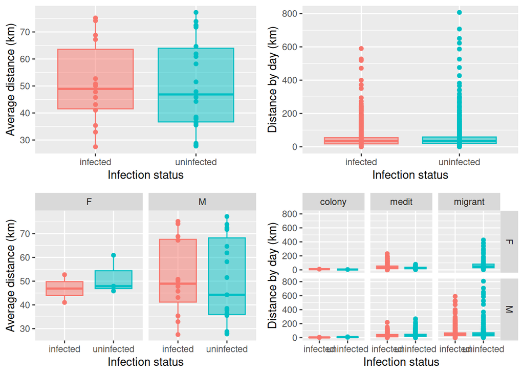

```r
ggarrange(plotG, plotH, plotI, plotJ, ncol=2, nrow=2)
```

**Migrants:**

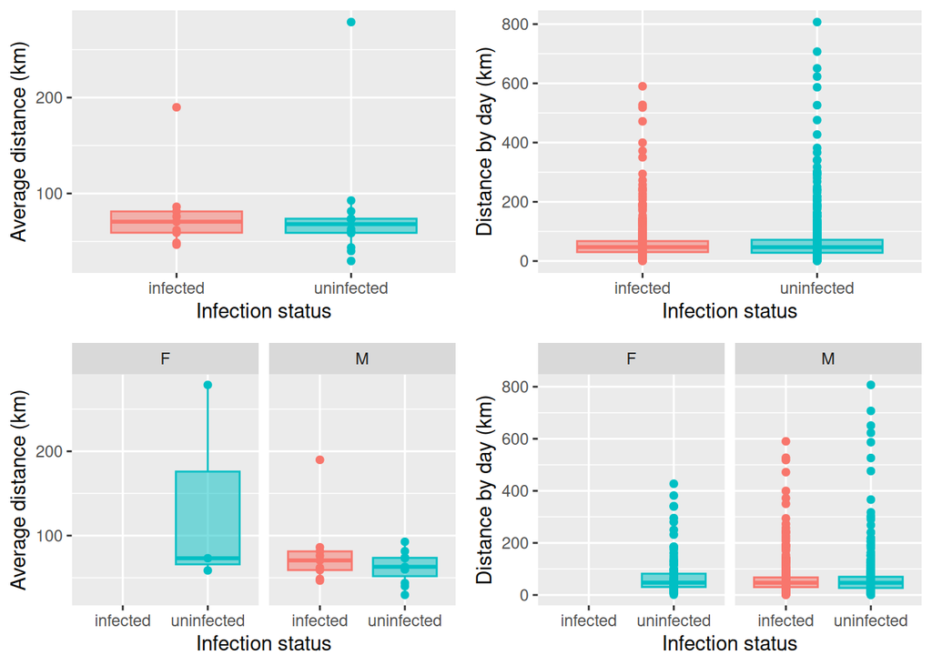

```r
ggarrange(plotK, plotL, plotM, plotN, ncol=2, nrow=2)
```

**Sedentary:**

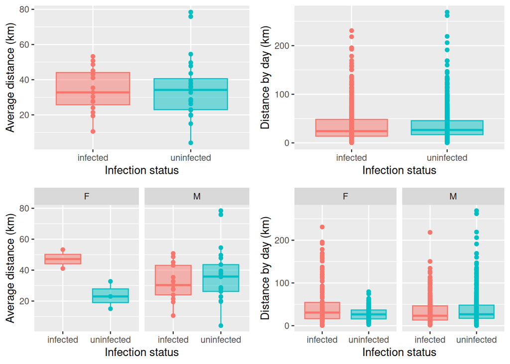

```r
ggarrange(plotO, plotP, plotQ, plotR, ncol=2, nrow=2)
```

## 2.2. Average daily flight distances

### 2.2.1. Migrant birds

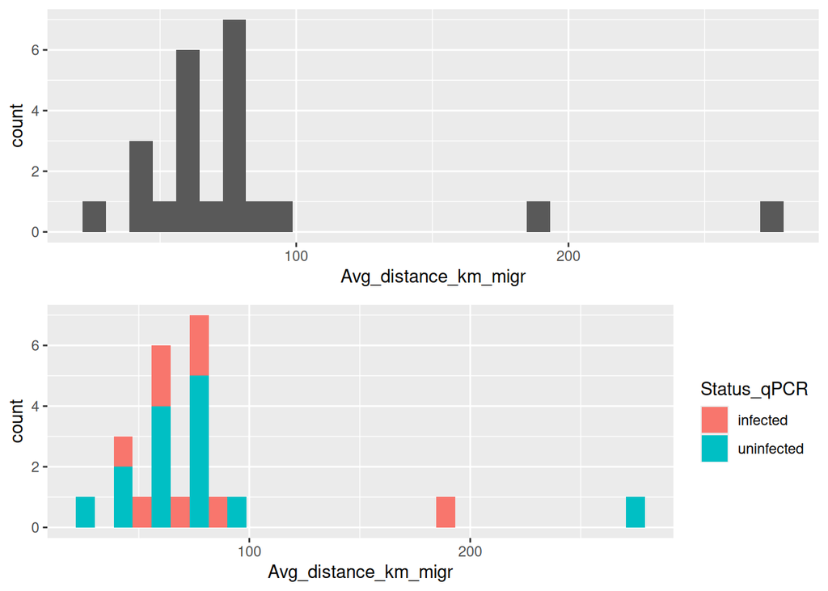

```r
i <- ggplot(data_distance_avg_migr, aes(x=Avg_distance_km_migr)) + geom_histogram()
j <- ggplot(data_distance_avg_migr, aes(x=Avg_distance_km_migr, fill=Status_qPCR)) + geom_histogram()
ggarrange(i,j, ncol=1, nrow=2)
```

```r
shap7 <- shapiro.test(data_distance_avg_migr$Avg_distance_km_migr)
shap8 <- shapiro.test(data_distance_avg_migr$Avg_distance_km_migr[data_distance_avg_migr$Status_qPCR == "infected"])
shap9 <- shapiro.test(data_distance_avg_migr$Avg_distance_km_migr[data_distance_avg_migr$Status_qPCR == "uninfected"])

shapiro_test_results_migr <- data.frame(
  Shapiro_test = c("Avg_distance_km_migr", "Avg_distance_km_migr - infected", "Avg_distance_km_migr - uninfected"),
  p_value = c(shap7$p.value, shap8$p.value, shap9$p.value))

shapiro_test_results_migr %>%
  kable(caption = "Shapiro results of Avg_distance_km_migr") %>%
  kable_styling(bootstrap_options = c("striped", "hover", "condensed", "responsive"))
```

Shapiro results of Avg_distance_km_migr

| Shapiro_test | p_value |
| --- | --- |
| Avg_distance_km_migr | 0.0000014 |
| Avg_distance_km_migr - infected | 0.0011903 |
| Avg_distance_km_migr - uninfected | 0.0000216 |

**All p-value < 0.05**

```r
leveneTest(data_distance_avg_migr$Avg_distance_km_migr ~ data_distance_avg_migr$Status_qPCR)
```

```
## Levene's Test for Homogeneity of Variance (center = median)
##       Df F value Pr(>F)
## group  1  0.0351 0.8532
##       21
```

**p-value > 0.05**  
Variances are egal but `data_distance_avg_migr$Avg_distance_km_migr` is not normally distributed. **We will use non-parametric tests but LMER models for which we will test the distribution of model residuals.**

**Wilcoxon rank-sum test:**

```r
wilcox.test(Avg_distance_km_migr ~ Status_qPCR, data = data_distance_avg_migr, exact = TRUE)
```

```
##
##  Wilcoxon rank sum exact test
##
## data:  Avg_distance_km_migr by Status_qPCR
## W = 70, p-value = 0.6883
## alternative hypothesis: true location shift is not equal to 0
```

**p-value = 0.6883**  
**There is no difference in mean of the average distance (km) traveled as migrants according to infection status.**

**LMER model:**  
We will test the influence of `Status_qPCR` on `Avg_distance_km_migr` using LMER models and then test for the distribution of model residuals. We include the variable `Status_qPCR` as a fixed effect and `Site` and `Year` as random effects in our full LMER model:

```r
lmer_avg_distance_migr_full <- lmer(Avg_distance_km_migr ~ Status_qPCR + (1|Site) + (1|Year), data=data_distance_avg_migr)
lmer_avg_distance_migr_null <- lmer(Avg_distance_km_migr ~ 1 + (1|Site) + (1|Year), data=data_distance_avg_migr)
AICc(lmer_avg_distance_migr_full)
```

```
## [1] 245.7209
```

```r
AICc(lmer_avg_distance_migr_null)
```

```
## [1] 250.5193
```

```r
anova(lmer_avg_distance_migr_full, lmer_avg_distance_migr_null, test="Chisq")
```

```
## Data: data_distance_avg_migr
## Models:
## lmer_avg_distance_migr_null: Avg_distance_km_migr ~ 1 + (1 | Site) + (1 | Year)
## lmer_avg_distance_migr_full: Avg_distance_km_migr ~ Status_qPCR + (1 | Site) + (1 | Year)
##                             npar    AIC    BIC  logLik -2*log(L)  Chisq Df
## lmer_avg_distance_migr_null    4 254.92 259.46 -123.46    246.92
## lmer_avg_distance_migr_full    5 256.92 262.59 -123.46    246.92 0.0036  1
##                             Pr(>Chisq)
## lmer_avg_distance_migr_null
## lmer_avg_distance_migr_full     0.9523
```

```r
tab_model(lmer_avg_distance_migr_full, lmer_avg_distance_migr_null, string.est = "IRR", show.aicc = TRUE, digits=2, show.ci = FALSE, show.intercept = FALSE)
```

|  | Avg_distance_km_migr |  | Avg_distance_km_migr |  |
| --- | --- | --- | --- | --- |
| Predictors | IRR | p | IRR | p |
| Status qPCR [uninfected] | -1.33 | 0.955 |  |  |
| Random Effects |  |  |  |  |
| σ<sup>2</sup> | 2947.05 |  | 2813.53 |  |
| τ<sub>00</sub> | 0.00 <sub>Year</sub> |  | 0.00 <sub>Year</sub> |  |
|  | 0.00 <sub>Site</sub> |  | 0.00 <sub>Site</sub> |  |
| N | 2 <sub>Site</sub> |  | 2 <sub>Site</sub> |  |
|  | 3 <sub>Year</sub> |  | 3 <sub>Year</sub> |  |
| Observations | 23 |  | 23 |  |
| Marginal R<sup>2</sup> / Conditional R<sup>2</sup> | 0.000 / NA |  | 0.000 / NA |  |
| AICc | 245.721 |  | 250.519 |  |

Based on these results, the best-fitted model is `1 + (1|Site) + (1|Year)`.  
We examine the best-fitted model:

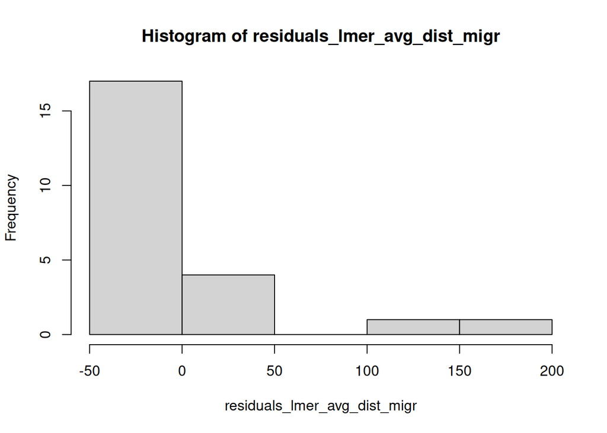

```r
residuals_lmer_avg_dist_migr <- residuals(lmer_avg_distance_migr_null)
hist(residuals_lmer_avg_dist_migr)
```

```r
shapiro.test(residuals(lmer_avg_distance_migr_null))
```

```
##
##  Shapiro-Wilk normality test
##
## data:  residuals(lmer_avg_distance_migr_null)
## W = 0.61671, p-value = 1.383e-06
```

**Conclusion**:  
**There is no significant difference between infected and uninfected birds that migrated**.

Some metrics:

```r
summary_avg_migr <- data_distance_avg_migr %>%
  group_by(Status_qPCR) %>%
  summarise(
    mean = mean(Avg_distance_km_migr, na.rm = TRUE),
    SD = sd(Avg_distance_km_migr),
    SE = sd(Avg_distance_km_migr, na.rm = TRUE) / sqrt(length(Avg_distance_km_migr)),
    n = length(Avg_distance_km_migr)
    )
kable(summary_avg_migr, align="lccc")
```

| Status_qPCR | mean | SD | SE | n |
| --- | --- | --- | --- | --- |
| infected | 80.01473 | 43.42554 | 14.47518 | 9 |
| uninfected | 78.68892 | 60.00119 | 16.03599 | 14 |

Infected migrant birds traveled around 80.01 km vs 78.69 km for uninfected ones.

### 2.2.2. Sedentary birds

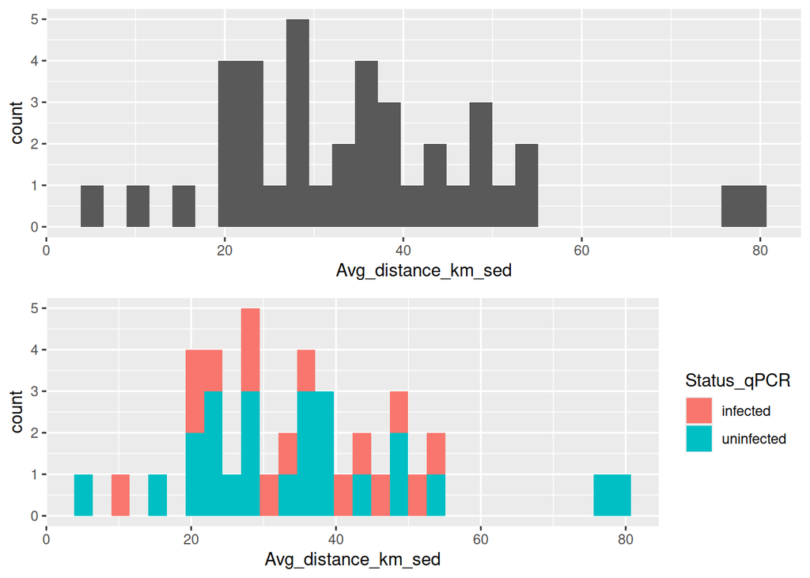

```r
k <- ggplot(data_distance_avg_sed, aes(x=Avg_distance_km_sed)) + geom_histogram()
l <- ggplot(data_distance_avg_sed, aes(x=Avg_distance_km_sed, fill=Status_qPCR)) + geom_histogram()
ggarrange(k,l, ncol=1, nrow=2)
```

```r
shap10 <- shapiro.test(data_distance_avg_sed$Avg_distance_km_sed)
shap11 <- shapiro.test(data_distance_avg_sed$Avg_distance_km_sed[data_distance_avg_sed$Status_qPCR == "infected"])
shap12 <- shapiro.test(data_distance_avg_sed$Avg_distance_km_sed[data_distance_avg_sed$Status_qPCR == "uninfected"])

shapiro_test_results_sed <- data.frame(
  Shapiro_test = c("Avg_distance_km_sed", "Avg_distance_km_sed - infected", "Avg_distance_km_sed - uninfected"),
  p_value = c(shap10$p.value, shap11$p.value, shap12$p.value))

shapiro_test_results_sed %>%
  kable(caption = "Shapiro results of Avg_distance_km_sed") %>%
  kable_styling(bootstrap_options = c("striped", "hover", "condensed", "responsive"))
```

Shapiro results of Avg_distance_km_sed

| Shapiro_test | p_value |
| --- | --- |
| Avg_distance_km_sed | 0.0992521 |
| Avg_distance_km_sed - infected | 0.8547504 |
| Avg_distance_km_sed - uninfected | 0.0749448 |

**All p-value > 0.05**

```r
leveneTest(data_distance_avg_sed$Avg_distance_km_sed ~ data_distance_avg_sed$Status_qPCR)
```

```
## Levene's Test for Homogeneity of Variance (center = median)
##       Df F value Pr(>F)
## group  1  0.4242 0.5189
##       37
```

**p-value > 0.05**  
Variances are egal and `data_distance_avg_sed$Avg_distance_km_sed` is normally distributed. **We will use parametric tests and LMER models for which we will test the distribution of model residuals.**

**Two Sample t-test:**

```r
t.test(data_distance_avg_sed$Avg_distance_km_sed ~ data_distance_avg_sed$Status_qPCR, var.equal = TRUE)
```

```
##
##  Two Sample t-test
##
## data:  data_distance_avg_sed$Avg_distance_km_sed by data_distance_avg_sed$Status_qPCR
## t = -0.21514, df = 37, p-value = 0.8308
## alternative hypothesis: true difference in means between group infected and group uninfected is not equal to 0
## 95 percent confidence interval:
##  -11.595394   9.369402
## sample estimates:
##   mean in group infected mean in group uninfected
##                 34.07293                 35.18593
```

**p = 0.8308 > 0.05**  
**There is no difference in mean of the average distance (km) traveled as sedentary according to infection status**.

**LMER model:**  
We will test the influence of `Status_qPCR` on `Avg_distance_km_sed` using LMER models and then test for the distribution of model residuals. We include the variable `Status_qPCR` as a fixed effect and `Site` and `Year` as random effects in our full LMER model:

```r
lmer_avg_distance_sed_full <- lmer(Avg_distance_km_sed ~ Status_qPCR + (1|Site) + (1|Year), data=data_distance_avg_sed)
lmer_avg_distance_sed_null <- lmer(Avg_distance_km_sed ~ 1 + (1|Site) + (1|Year), data=data_distance_avg_sed)
AICc(lmer_avg_distance_sed_full)
```

```
## [1] 326.1859
```

```r
AICc(lmer_avg_distance_sed_null)
```

```
## [1] 328.7099
```

```r
anova(lmer_avg_distance_sed_full, lmer_avg_distance_sed_null, test="Chisq")
```

```
## Data: data_distance_avg_sed
## Models:
## lmer_avg_distance_sed_null: Avg_distance_km_sed ~ 1 + (1 | Site) + (1 | Year)
## lmer_avg_distance_sed_full: Avg_distance_km_sed ~ Status_qPCR + (1 | Site) + (1 | Year)
##                            npar    AIC    BIC  logLik -2*log(L)  Chisq Df
## lmer_avg_distance_sed_null    4 331.51 338.16 -161.75    323.51
## lmer_avg_distance_sed_full    5 333.46 341.78 -161.73    323.46 0.0506  1
##                            Pr(>Chisq)
## lmer_avg_distance_sed_null
## lmer_avg_distance_sed_full      0.822
```

```r
tab_model(lmer_avg_distance_sed_full, lmer_avg_distance_sed_null, string.est = "IRR", show.aicc = TRUE, digits=2, show.ci = FALSE, show.intercept = FALSE)
```

|  | Avg_distance_km_sed |  | Avg_distance_km_sed |  |
| --- | --- | --- | --- | --- |
| Predictors | IRR | p | IRR | p |
| Status qPCR [uninfected] | 1.13 | 0.828 |  |  |
| Random Effects |  |  |  |  |
| σ<sup>2</sup> | 237.62 |  | 231.69 |  |
| τ<sub>00</sub> | 13.93 <sub>Year</sub> |  | 13.52 <sub>Year</sub> |  |
|  | 0.00 <sub>Site</sub> |  | 0.00 <sub>Site</sub> |  |
| N | 2 <sub>Site</sub> |  | 2 <sub>Site</sub> |  |
|  | 3 <sub>Year</sub> |  | 3 <sub>Year</sub> |  |
| Observations | 39 |  | 39 |  |
| Marginal R<sup>2</sup> / Conditional R<sup>2</sup> | 0.001 / NA |  | 0.000 / NA |  |
| AICc | 326.186 |  | 328.710 |  |

Based on these results, the best-fitted model is `1 + (1|Site) + (1|Year)`.  
We examine the best-fitted model:

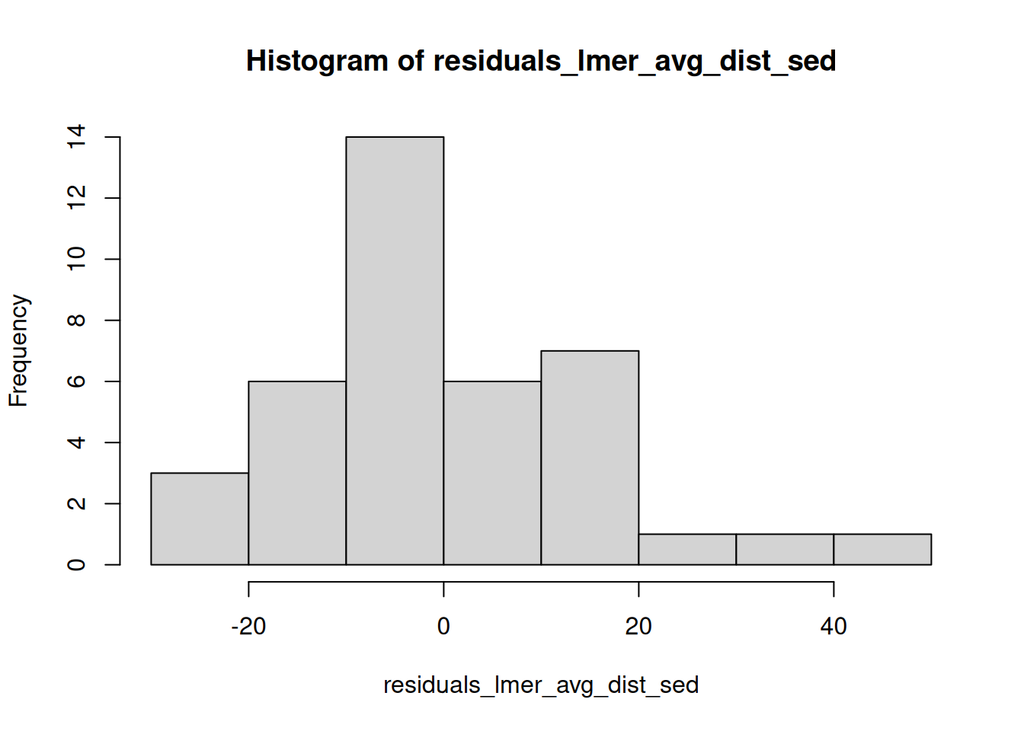

```r
residuals_lmer_avg_dist_sed <- residuals(lmer_avg_distance_sed_null)
hist(residuals_lmer_avg_dist_sed)
```

```r
shapiro.test(residuals(lmer_avg_distance_sed_null))
```

```
##
##  Shapiro-Wilk normality test
##
## data:  residuals(lmer_avg_distance_sed_null)
## W = 0.95643, p-value = 0.1354
```

**Conclusion**:  
**There is no significant difference between infected and uninfected birds during their sedentary phase**.

Some metrics:

```r
summary_avg_sed <- data_distance_avg_sed %>%
  group_by(Status_qPCR) %>%
  summarise(
    mean = mean(Avg_distance_km_sed, na.rm = TRUE),
    SD = sd(Avg_distance_km_sed),
    SE = sd(Avg_distance_km_sed, na.rm = TRUE) / sqrt(length(Avg_distance_km_sed)),
    n = length(Avg_distance_km_sed)
    )
kable(summary_avg_sed, align="lccc")
```

| Status_qPCR | mean | SD | SE | n |
| --- | --- | --- | --- | --- |
| infected | 34.07293 | 12.64357 | 3.264556 | 15 |
| uninfected | 35.18593 | 17.32438 | 3.536324 | 24 |

Infected sedentary birds traveled around 34.07 km vs 35.19 km for uninfected ones.

## 2.3. Daily flight distances

### 2.3.1. Migrant birds

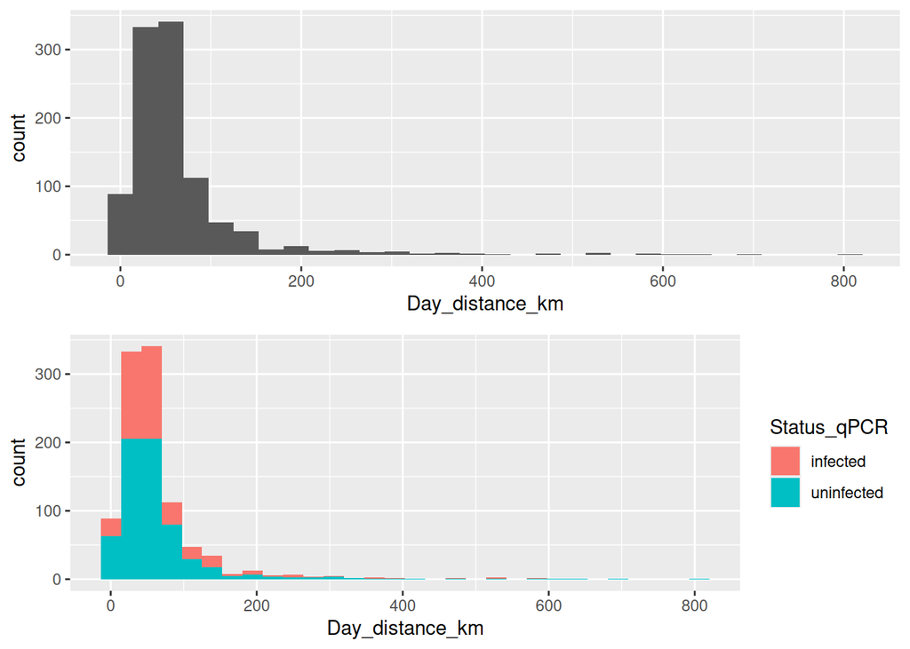

```r
m <- ggplot(data_distance_day_migr, aes(x=Day_distance_km)) + geom_histogram()
n <- ggplot(data_distance_day_migr, aes(x=Day_distance_km, fill=Status_qPCR)) + geom_histogram()
ggarrange(m,n, ncol=1, nrow=2)
```

```r
shapiro.test(data_distance_day_migr$Day_distance_km)
```

```
##
##  Shapiro-Wilk normality test
##
## data:  data_distance_day_migr$Day_distance_km
## W = 0.56455, p-value < 2.2e-16
```

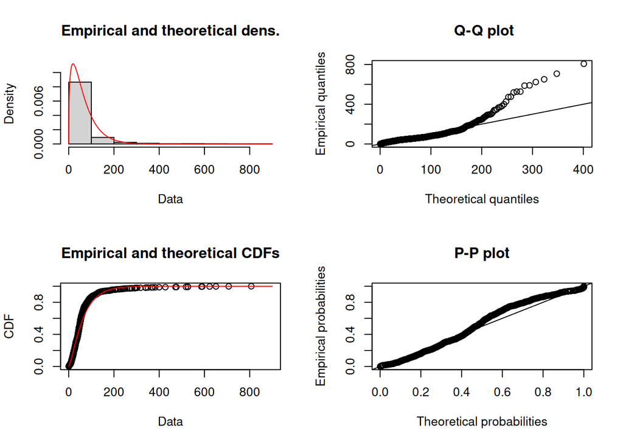

```r
fit_gamma_migr <- fitdist(data_distance_day_migr$Day_distance_km, "gamma")
fit_lognormal_migr <- fitdist(data_distance_day_migr$Day_distance_km, "lnorm")
plot(fit_gamma_migr)
```

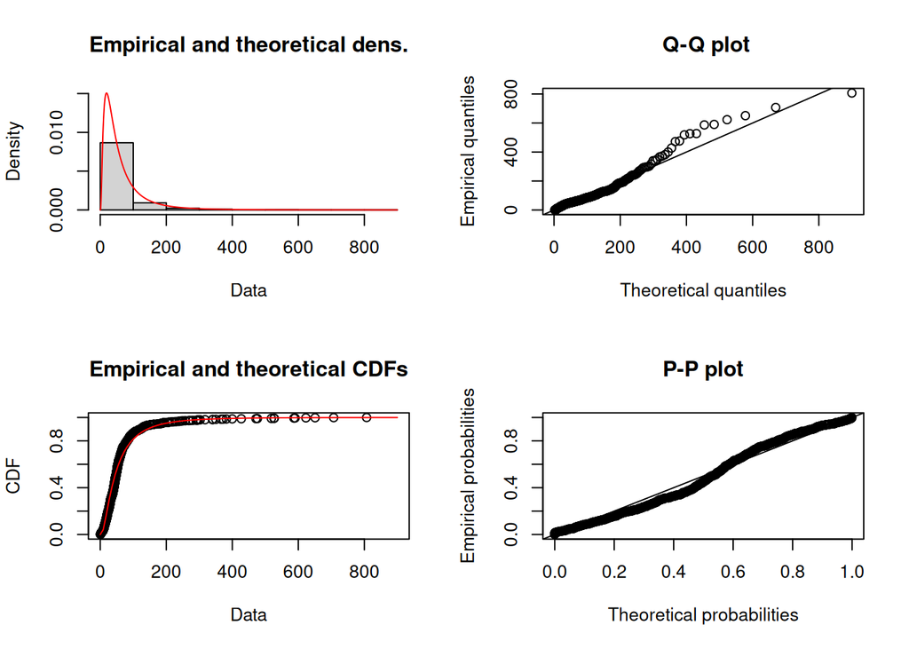

```r
plot(fit_lognormal_migr)
```

```r
gofstat(list(fit_gamma_migr, fit_lognormal_migr))
```

```
## Goodness-of-fit statistics
##                              1-mle-gamma 2-mle-lnorm
## Kolmogorov-Smirnov statistic   0.1132485  0.08195589
## Cramer-von Mises statistic     3.2106032  2.08329918
## Anderson-Darling statistic    18.1422119 11.51067954
##
## Goodness-of-fit criteria
##                                1-mle-gamma 2-mle-lnorm
## Akaike's Information Criterion    10480.03    10417.26
## Bayesian Information Criterion    10489.88    10427.11
```

Based on these results, we include the variables `Status_qPCR` in interaction as a fixed effect and `Site`, `Year`, and `Sample` as random effects in our full **LMER model with log-transformed data**, then test for distribution of model residuals:

```r
data_distance_day_migr$log_distance_day <- log10(data_distance_day_migr$Day_distance_km)

lmer_day_distance_migr_full <- lmer(log_distance_day ~ Status_qPCR + (1|Site) + (1|Year) + (1|Sample), data = data_distance_day_migr)
lmer_day_distance_migr_null <- lmer(log_distance_day ~ 1 + (1|Site) + (1|Year) + (1|Sample), data = data_distance_day_migr)
anova(lmer_day_distance_migr_full, lmer_day_distance_migr_null, test="Chisq")
```

```
## Data: data_distance_day_migr
## Models:
## lmer_day_distance_migr_null: log_distance_day ~ 1 + (1 | Site) + (1 | Year) + (1 | Sample)
## lmer_day_distance_migr_full: log_distance_day ~ Status_qPCR + (1 | Site) + (1 | Year) + (1 | Sample)
##                             npar    AIC    BIC logLik -2*log(L)  Chisq Df
## lmer_day_distance_migr_null    5 953.21 977.83 -471.6    943.21
## lmer_day_distance_migr_full    6 955.20 984.76 -471.6    943.20 0.0023  1
##                             Pr(>Chisq)
## lmer_day_distance_migr_null
## lmer_day_distance_migr_full     0.9616
```

```r
tab_model(lmer_day_distance_migr_full, lmer_day_distance_migr_null, string.est = "IRR", show.aicc = TRUE, digits=2, show.ci = FALSE, show.intercept = FALSE)
```

|  | log_distance_day |  | log_distance_day |  |
| --- | --- | --- | --- | --- |
| Predictors | IRR | p | IRR | p |
| Status qPCR [uninfected] | -0.00 | 0.969 |  |  |
| Random Effects |  |  |  |  |
| σ<sup>2</sup> | 0.14 |  | 0.14 |  |
| τ<sub>00</sub> | 0.03 <sub>Sample</sub> |  | 0.03 <sub>Sample</sub> |  |
|  | 0.00 <sub>Year</sub> |  | 0.00 <sub>Year</sub> |  |
|  | 0.00 <sub>Site</sub> |  | 0.00 <sub>Site</sub> |  |
| N | 2 <sub>Site</sub> |  | 2 <sub>Site</sub> |  |
|  | 3 <sub>Year</sub> |  | 3 <sub>Year</sub> |  |
|  | 23 <sub>Sample</sub> |  | 23 <sub>Sample</sub> |  |
| Observations | 1018 |  | 1018 |  |
| Marginal R<sup>2</sup> / Conditional R<sup>2</sup> | 0.000 / NA |  | 0.000 / NA |  |
| AICc | 963.422 |  | 958.091 |  |

Based on these results, the best-fitted model is `1 + (1|Site) + (1|Year) + (Sample)`.  
We examine the best-fitted model:

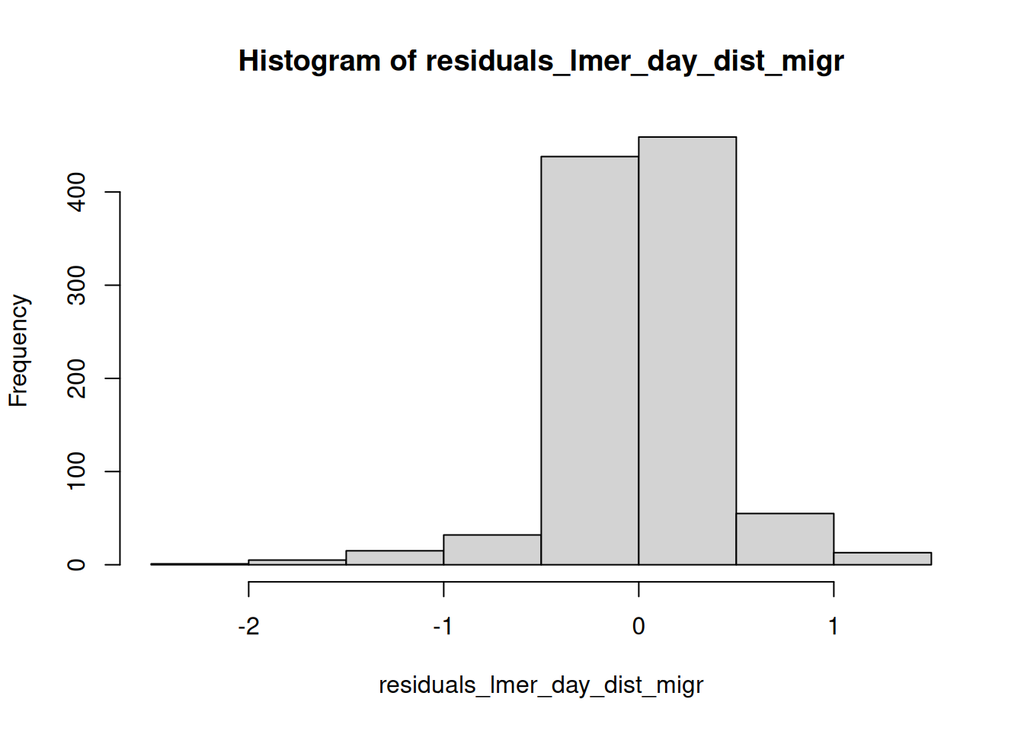

```r
residuals_lmer_day_dist_migr <- residuals(lmer_day_distance_migr_null)
hist(residuals_lmer_day_dist_migr)
```

```r
shapiro.test(residuals(lmer_day_distance_migr_null))
```

```
##
##  Shapiro-Wilk normality test
##
## data:  residuals(lmer_day_distance_migr_null)
## W = 0.92812, p-value < 2.2e-16
```

Conclusion:  
**The infection status doesn’t influence the daily distances traveled by migrant birds**.

### 2.3.2. Sedentary birds

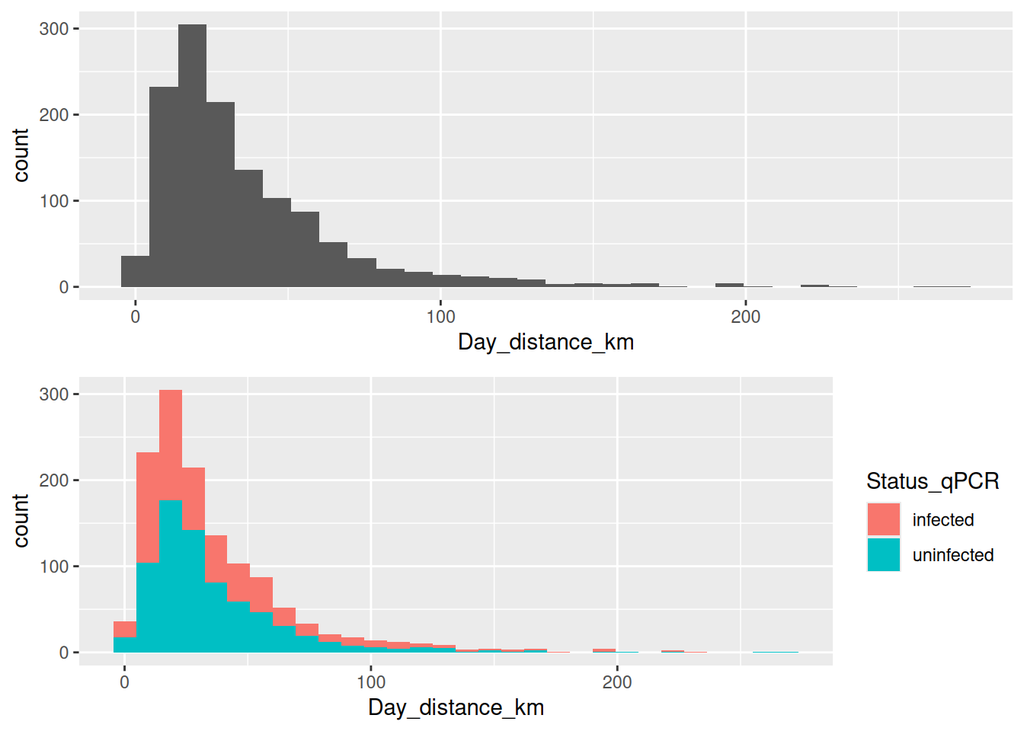

```r
o <- ggplot(data_distance_day_sed, aes(x=Day_distance_km)) + geom_histogram()
p <- ggplot(data_distance_day_sed, aes(x=Day_distance_km, fill=Status_qPCR)) + geom_histogram()
ggarrange(o,p, ncol=1, nrow=2)
```

```r
shapiro.test(data_distance_day_sed$Day_distance_km)
```

```
##
##  Shapiro-Wilk normality test
##
## data:  data_distance_day_sed$Day_distance_km
## W = 0.76873, p-value < 2.2e-16
```

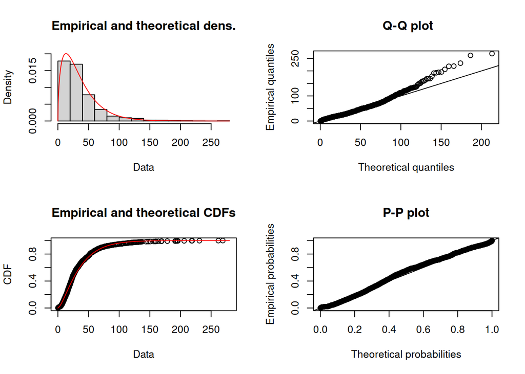

```r
fit_gamma_sed <- fitdist(data_distance_day_sed$Day_distance_km, "gamma")
fit_lognormal_sed <- fitdist(data_distance_day_sed$Day_distance_km, "lnorm")
plot(fit_gamma_sed)
```

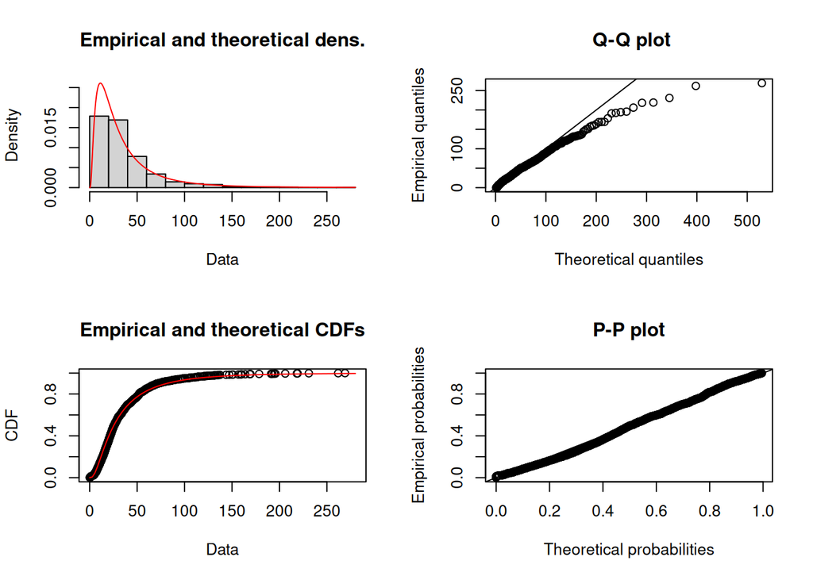

```r
plot(fit_lognormal_sed)
```

```r
gofstat(list(fit_gamma_sed, fit_lognormal_sed))
```

```
## Goodness-of-fit statistics
##                              1-mle-gamma 2-mle-lnorm
## Kolmogorov-Smirnov statistic  0.05822355   0.0511699
## Cramer-von Mises statistic    1.16841052   0.7751169
## Anderson-Darling statistic    6.74537527   5.5868493
##
## Goodness-of-fit criteria
##                                1-mle-gamma 2-mle-lnorm
## Akaike's Information Criterion    11844.37    11902.95
## Bayesian Information Criterion    11854.72    11913.30
```

Based on these results, we include the variables `Status_qPCR` in interaction as a fixed effect and `Site`, `Year`, and `Sample` as random effects in our full **LMER model with log-transformed data**, then test for distribution of model residuals:

```r
data_distance_day_sed$log_distance_day <- log10(data_distance_day_sed$Day_distance_km)

lmer_day_distance_sed_full <- lmer(log_distance_day ~ Status_qPCR + (1|Site) + (1|Year) + (1|Sample), data = data_distance_day_sed)
lmer_day_distance_sed_null <- lmer(log_distance_day ~ 1 + (1|Site) + (1|Year) + (1|Sample), data = data_distance_day_sed)
anova(lmer_day_distance_sed_full, lmer_day_distance_sed_null, test="Chisq")
```

```
## Data: data_distance_day_sed
## Models:
## lmer_day_distance_sed_null: log_distance_day ~ 1 + (1 | Site) + (1 | Year) + (1 | Sample)
## lmer_day_distance_sed_full: log_distance_day ~ Status_qPCR + (1 | Site) + (1 | Year) + (1 | Sample)
##                            npar    AIC    BIC  logLik -2*log(L)  Chisq Df
## lmer_day_distance_sed_null    5 1093.0 1118.9 -541.51    1083.0
## lmer_day_distance_sed_full    6 1094.9 1125.9 -541.44    1082.9 0.1328  1
##                            Pr(>Chisq)
## lmer_day_distance_sed_null
## lmer_day_distance_sed_full     0.7156
```

```r
tab_model(lmer_day_distance_sed_full, lmer_day_distance_sed_null, string.est = "IRR", show.aicc = TRUE, digits=2, show.ci = FALSE, show.intercept = FALSE)
```

|  | log_distance_day |  | log_distance_day |  |
| --- | --- | --- | --- | --- |
| Predictors | IRR | p | IRR | p |
| Status qPCR [uninfected] | 0.03 | 0.689 |  |  |
| Random Effects |  |  |  |  |
| σ<sup>2</sup> | 0.13 |  | 0.13 |  |
| τ<sub>00</sub> | 0.04 <sub>Sample</sub> |  | 0.04 <sub>Sample</sub> |  |
|  | 0.00 <sub>Year</sub> |  | 0.00 <sub>Year</sub> |  |
|  | 0.00 <sub>Site</sub> |  | 0.00 <sub>Site</sub> |  |
| N | 2 <sub>Site</sub> |  | 2 <sub>Site</sub> |  |
|  | 3 <sub>Year</sub> |  | 3 <sub>Year</sub> |  |
|  | 39 <sub>Sample</sub> |  | 39 <sub>Sample</sub> |  |
| Observations | 1307 |  | 1307 |  |
| Marginal R<sup>2</sup> / Conditional R<sup>2</sup> | 0.002 / NA |  | 0.000 / NA |  |
| AICc | 1102.635 |  | 1097.372 |  |

Based on these results, the best-fitted model is `1 + (1|Site) + (1|Year) + (Sample)`.  
We examine the best-fitted model:

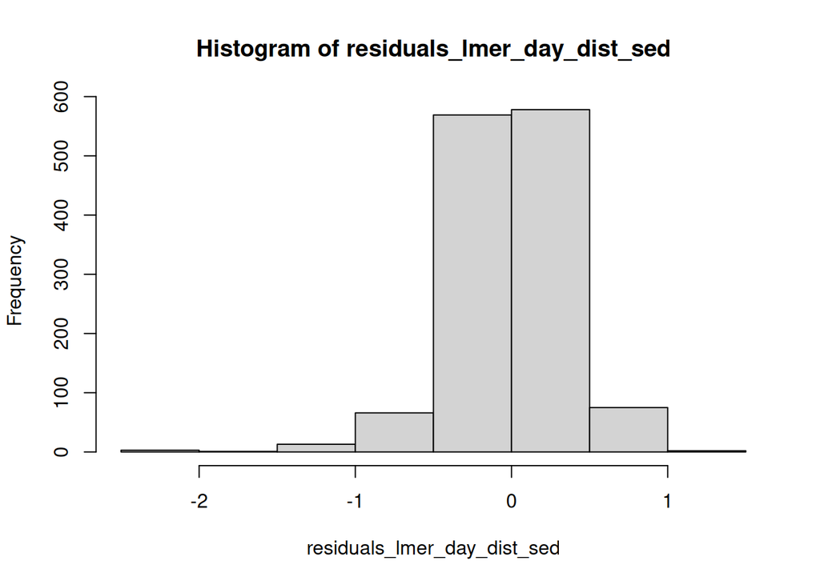

```r
residuals_lmer_day_dist_sed <- residuals(lmer_day_distance_sed_null)
hist(residuals_lmer_day_dist_sed)
```

```r
shapiro.test(residuals(lmer_day_distance_sed_null))
```

```
##
##  Shapiro-Wilk normality test
##
## data:  residuals(lmer_day_distance_sed_null)
## W = 0.9497, p-value < 2.2e-16
```

Conclusion:  
**The infection status doesn’t influence the daily distances traveled by sedentary birds**.

# 3. Summary

The infection status **doesn’t influence**:  
-**the fledging age** (Two Sample t-test, p-value = 0.88; LMER, p-value ANOVA vs null = 0.39, AICc = 202.89 vs 204.58),  
-**the age of departure on migration** (Permutation-based one-way test, p-value = 0.90; LMER, p-value ANOVA vs null = 0.91, AICc = 143.73 vs 144.56),  
-**the overall migration strategy** (Fisher’s test, p-value = 1; GLMER, p-value ANOVA vs null = 0.64, AICc = 58.84 vs 56.35).

**The infection doesn’t influence the average or daily distances traveled by birds, migrant or sedentary**.